# Data Science 1: Machine Learning Concepts Assignment

# 1. Supervised learning with penalized models and PCA

## Data

The goal for this question is to predict the property values (lot value + building value) of the properties in Manhattan New York. I have used the ‘Housing Development’ data set that is borrowed from the ‘R for Everyone’ book by Jared Lander. The dataset has a single table that includes 31746 observations. The data contains 46 variables that describe the various characteristics of the property in terms of location , size, features, and area. The target variable is logarithm of total property value in Dollars. The data was already cleaned and had no NA’s.

## a. Exploratory Data Analysis

I started with carrying out some exploratory data analysis. I analyzed the distribution of Property Values via a histogram and observed a strongly skewed graph with a right long tail. Hence, to normalize the distribution, I plotted the logarithmic of total property value:

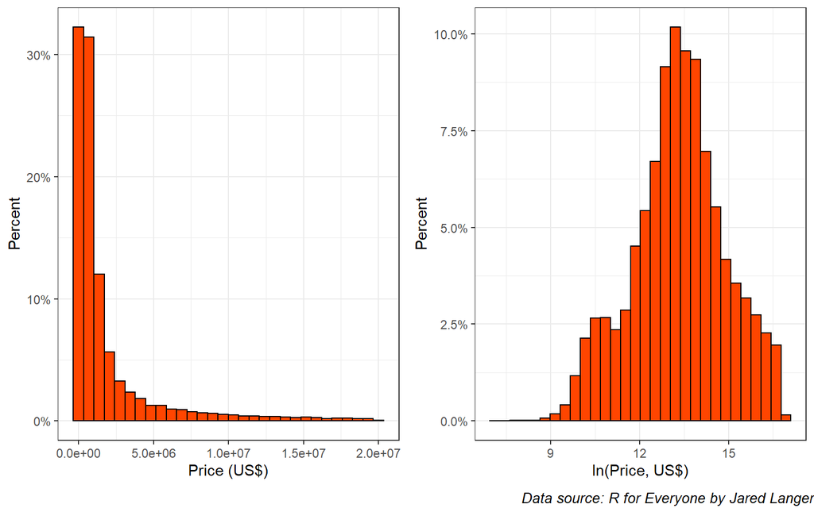

I also took log of some other variables which appeared skewed and normalized them through taking logarithms. We explore some scatter plots and further distributions of some explanatory variables in **Figure 1** andcorrelation between all the explanatory variables in **Figure 2** in the Appendix.

## b. Building Regression Models

I have used the Forward Selection approach to construct several models and then use the Cross Validation Root Mean Squared Error (RMSE) Loss function to determine which selection of group of variables gives us the best predictive performance. I constructed 3 OLS models using forward approach in which we add more variables increasing model complexity. The first OLS model is based on the coefficient correlation chart as a base benchmark model. I have included those explanatory variables which have the highest correlation with the target variable (logTotalValue).

The problem with using correlations as a basis of choosing explanatory variables can result in omitted variable bias. A variable (x1) when analyzed individually might show strong correlation with the target variable(y) but it can be correlated with another independent variable (x2) as well. In isolation we see that the X1 is a good predictor of y but once the effects of x2 are partialled out by including x2 in the model, no such relationship remains.

To construct the formula of the second model, I used domain knowledge to add explanatory variables which are considered most important in valuing a property. For the 3rd OLS Model, I included all variables (excluding ID, TotalValue, ZoneDist3, ZoneDist4) as a complete model to be able to compare other models that we will run using Regularization algorithms. For the readers convenience, I have written down the variables to be used in each model below:

**Versions of the Total Valuation Prediction Models**

| Model | Predictor Variables |
| --- | --- |
| OLS Model 1 | logTotalValue ~ logBldgArea + logNumFloors + logBuiltFAR + logLotFront + logLotArea + logUnitsTotal + BuiltFAR + NumFloors + BldgArea |
| OLS Model 2 | logTotalValue ~ LandUse + LotArea + BldgArea + NumFloors + UnitsRes + UnitsTotal + Proximity + IrregularLot + HistoricDistrict + ZoneDist1 +ZoneDist2 + LotDepth +BldgDepth + BasementType + logLotArea … |
| OLS Model 3 | logTotalValue ~ SchoolDistrict + Council + FireService + PolicePrct + HealthArea + ZoneDist1 + ZoneDist2 + Class + LandUse + Easements + OwnerType + LotArea + BldgArea + ComArea + ResArea + OfficeArea… |
| Regularization Models | logTotalValue ~ SchoolDistrict + Council + FireService + PolicePrct + HealthArea + ZoneDist1 + ZoneDist2 + Class + LandUse + Easements + OwnerType + LotArea + BldgArea + ComArea + ResArea + OfficeArea… |

We split our data randomly into 70/30 ratio with 30% used as holdout set while the remaining 70% will be used for Cross Validation training on 10 folds of train and validation sets.

```r
set.seed(1234)
train_indices <- as.integer(createDataPartition(data$logTotalValue, p = 0.70, list = FALSE))
data_train <- data[train_indices, ]
data_holdout <- data[-train_indices, ]
```

## c. OLS Linear Regression

I trained and tested all the regression models using cross validation (CV) on the training set and calculated the R-squared, BIC, and the Root Mean Squared Error (RMSE). The results are shown below:

**Comparing Model Fit measures**

| Model | N predictors | R-squared | BIC | CV RMSE |
| --- | --- | --- | --- | --- |
| OLS Model 1 | 9 | 0.631 | 61208 | 0.959 |
| OLS Model 2 | 40 | 0.739 | 53883 | 0.810 |
| OLS Model 3 | 233 | 0.894 | 35823 | 0.525 |

The R-squared improves as we add more predictor variables into the models. Model 3 which contains all the variables as well the logs gives an R-square of 0.89 which means the that this model explains 89% of the variation in log total value. Model 3 provided the lowest BIC of the 3 models of 35823 (lower values of BIC indicate better performance). CV RMSE improves as we go from Model 1 to Model 3. Model 3 produces CV RMSE of 0.525 which makes it the best model out of the 3 OLS models in terms of providing the best predictive performance.

## d. Regularization Methods

### i. Lasso Regression

Lasso is a model that penalizes models for complexity. We assign it a big set of predictors and the model returns with an estimated regression that has fewer coefficients. The missing coefficients are actually penalized and assigned a value of zero. For the variables that remain, it gives estimated coefficients. We use Cross validation to arrive at the λ value that can give us the lowest RMSE. In our analysis, the λ value of 0.0005 provided the lowest RMSE of 0.525 which puts it at par with OLS Model 3.

**Lasso Model Coefficients**

| variable | coefficient |
| --- | --- |
| (Intercept) | 13.3318254 |
| SchoolDistrict01 | 0.0342649 |
| SchoolDistrict02 | 0.1195758 |
| SchoolDistrict03 | 0.0000000 |
| SchoolDistrict04 | -0.0328904 |
| SchoolDistrict05 | 0.0000000 |
| SchoolDistrict06 | -0.0986530 |
| SchoolDistrict10 | 0.0000000 |
| Council2 | 0.0108562 |
| Council3 | 0.0122144 |
| Council4 | 0.0207633 |
| Council5 | -0.0362219 |
| Council6 | 0.0000000 |
| Council7 | -0.0736743 |
| Council8 | -0.0629938 |
| Council9 | -0.1366608 |
| Council10 | -0.0608569 |
| FireServiceLadder | -0.0093563 |
| FireServiceSquad | 0.0054425 |
| PolicePrct5 | -0.0383478 |
| PolicePrct6 | 0.0264054 |
| PolicePrct7 | -0.0142340 |
| PolicePrct9 | -0.0404746 |
| PolicePrct10 | 0.0000402 |
| PolicePrct13 | 0.0040356 |
| PolicePrct14 | 0.0091679 |
| PolicePrct17 | 0.0311276 |
| PolicePrct18 | 0.0006896 |
| PolicePrct19 | 0.1134310 |
| PolicePrct20 | 0.0798472 |

[output cut: 213 more lines]

The graph below shows how our RMSE varies across different λ values:

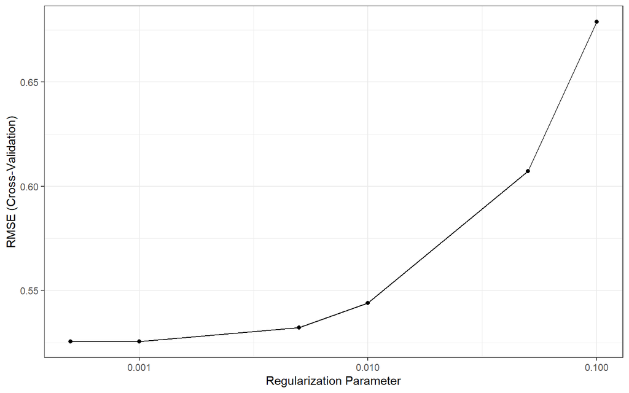

### ii. Ridge Regression

The graph below shows how our RMSE varies across different λ values:

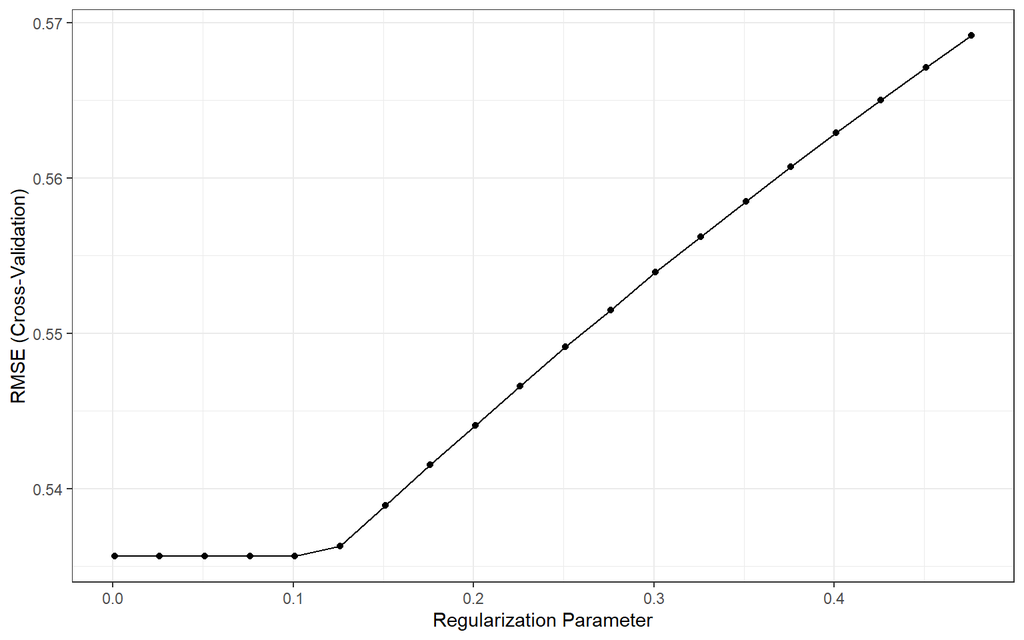

### iii. Elastic Net Regression

The graph below shows how our RMSE varies across different λ values:

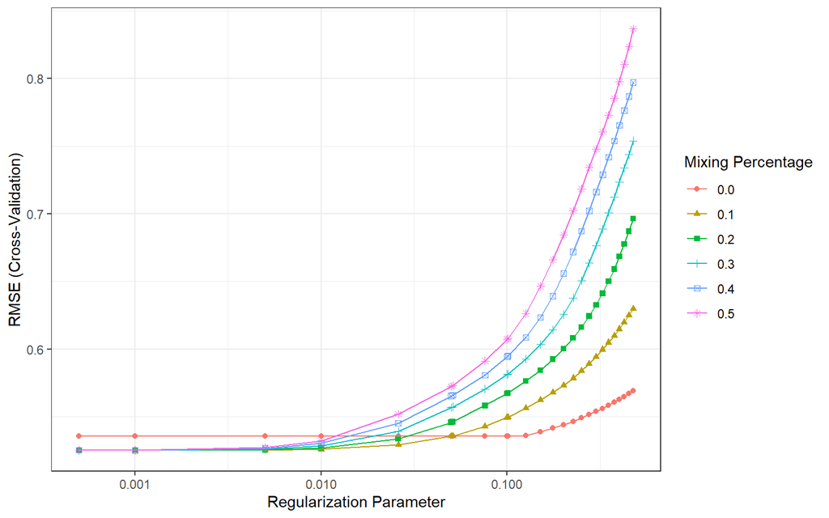

## f. Principal Component Analysis via pcr

I tried to improve the linear model by using PCA for dimensionality reduction. I centered and scaled the variables and used ‘pcr’ to conduct a search for the optimal number of principal components. The optimal number of principal components came out to be 124.

## g. Principal Component Analysis on Penalized Models

I used PCA prior to estimating penalized models via preProcess by applying the optimal number of principal components found before which was 124. I also removed features with zero variance. The model fit has slightly decreased in all penalized models as well having lost model interpretability. Among penalized models with pca preprocessing, Elastic Net performed the best with RMSE 0.546.

The results of the predictive performance of all the models that we have tried out are listed into one table below for comparison:

**List of Models CV RSME**

|  | CV RMSE |
| --- | --- |
| OLS Model 1 | 0.959 |
| OLS Model 2 | 0.810 |
| OLS Model 3 | 0.525 |
| OLS Model(PCA) | 0.673 |
| LASSO | 0.525 |
| LASSO(PCA) | 0.548 |
| Ridge | 0.536 |
| Ridge(PCA) | 0.556 |
| Elastic Net | 0.525 |
| Elastic Net(PCA) | 0.546 |

## h. Predicting on test set

The table shows that the best predictors of the data were OLS Model 3, Lasso, and the Elastic Net model with RMSE 0.525. We will use the Lasso model as our bets model due to less number of variables which means a less complex model as well as easier interpretability. With our Lasso model, I tested on the holdout set and got RMSE of 0.558. This means we can expect to make an error of $0.558 (log value) when using our model on the live data in the New York property valuation market on the assumption that the external validity is high.

# 2. Clustering on the USArrests dataset

Before applying clustering methods, I will bring all variables to the same scale as clusters may be sensitive to details such as different scales of distance for different variables. I then used the nbClust indices to choose number of clusters. ‘nbClust’ calculates 30 indices based on various principles and chooses cluster by majority rule. In my analysis, ‘nbClust’ stated that 11 of the indices proposed 2 as the best number of clusters.

```
## Among all indices:
## ===================
## * 2 proposed  0 as the best number of clusters
## * 11 proposed  2 as the best number of clusters
## * 2 proposed  3 as the best number of clusters
## * 1 proposed  4 as the best number of clusters
## * 1 proposed  5 as the best number of clusters
## * 7 proposed  6 as the best number of clusters
## * 1 proposed  9 as the best number of clusters
## * 1 proposed  10 as the best number of clusters
##
## Conclusion
## =========================
## * According to the majority rule, the best number of clusters is  2 .
```

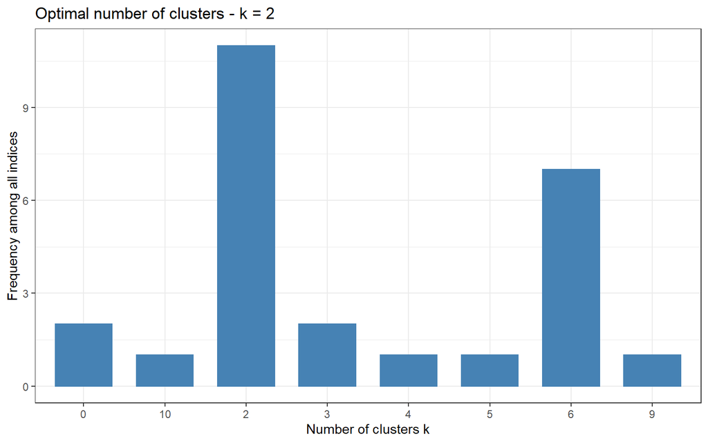

Then i plotted the clusters on to a graph. The clustering is done via the k-means method, which aims to partition the points into k groups such that the sum of squares from points to the assigned cluster centers is minimized. I used 25 ‘nstarts’ in the configuration of the algorithms. ‘nstart’ is the number of times the algorithm initializes with new random centers and hence it is highly recommended to pick higher value for it to stabilize the algorithm. I plotted observations colored by clusters in the space of urban population and Murder variable. The clusters are shown below:

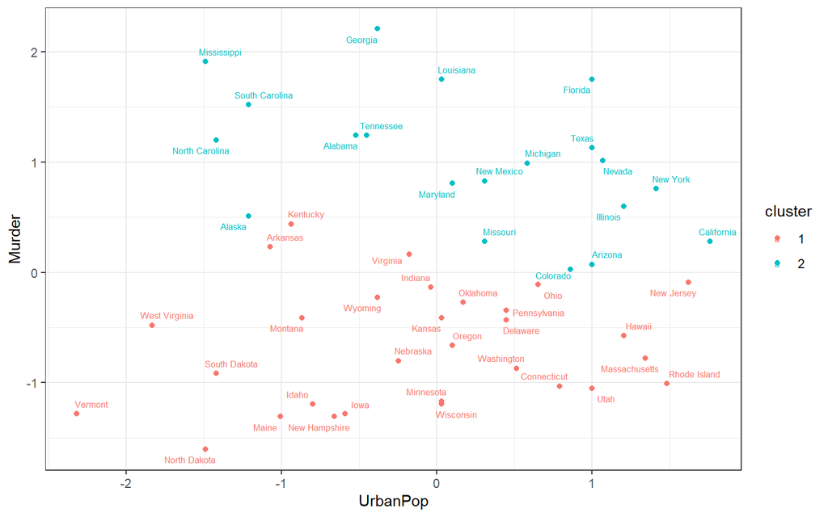

It is a good idea to plot the cluster results. These can be used to assess the choice of the number of clusters as well as comparing two different clusters

Sometimes we want to visualize the whole data in a colored scatter plot. The problem is that the data contains more than 2 variables and the question is what variables to choose for the xy scatter plot.

A solution is to reduce the number of dimensions by applying a dimensionality reduction algorithm known as Principal Component Analysis (PCA), that operates on the four variables and outputs two new variables (that represent the original variables) that I can use to do the plot.

So i carried out PCA on the data and got the first two principal components for all observations. I plotted two clusters as defined by the first two principal components.

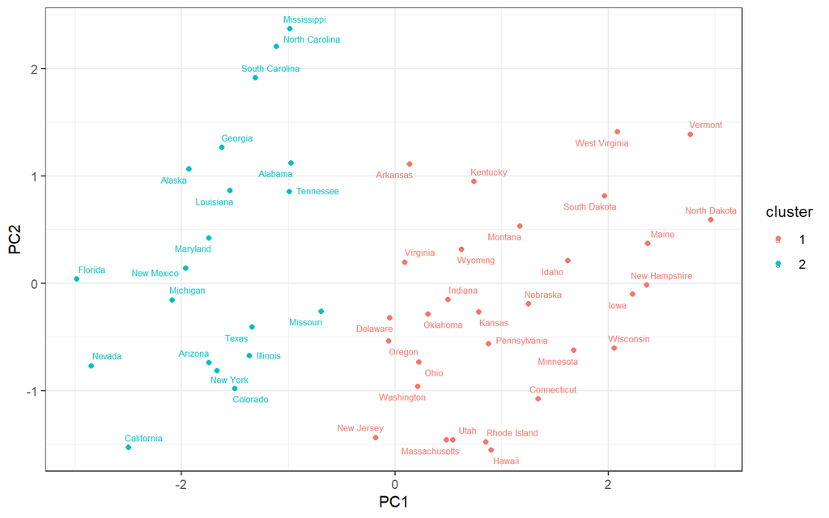

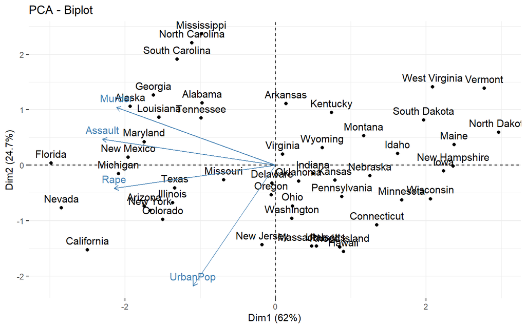

# 3. PCA of high-dimensional data

For this task, I performed PCA on 40 observations of 1000 variables. Data consists of measurements of genes of tissues of healthy and diseased patients.

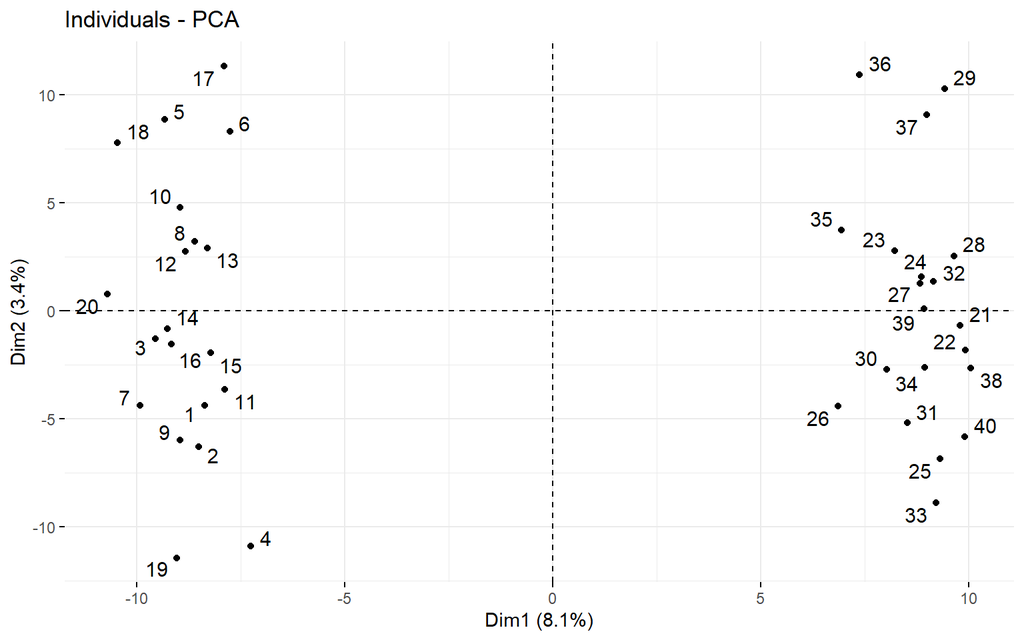

We can see that PC1 matters a lot hence we look at features that have high loadings for the first principal component to determine which individual features matter most in separating the diseased from the healthy. The top 10 most important features are visualized below:

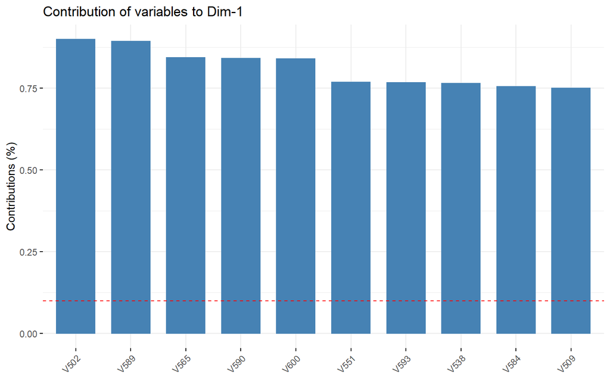

The top 3 most important features based on the largest coordinates (in absolute terms) are V502, V589, and V565. With the top two features, I plotted the observations in the coordinate system defined by these two original features:

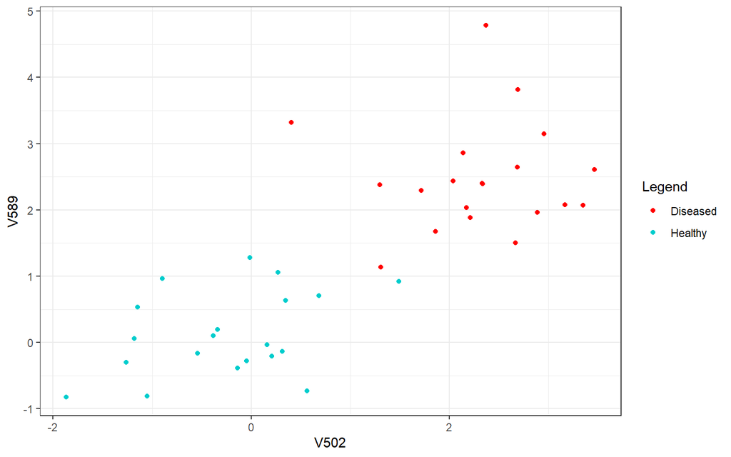

We can see a distinct separation on the graph however the separation on the PC1-PC2 chart was much more separated.

# Appendix

**Figure 1**

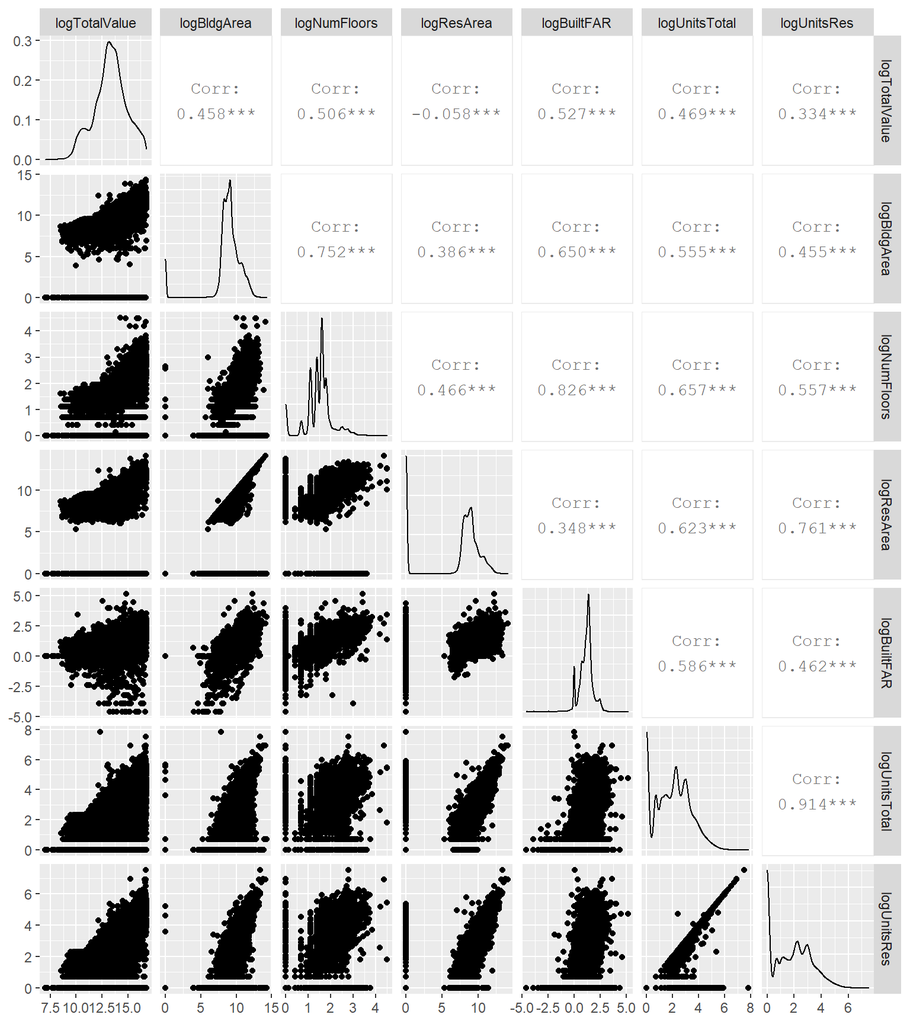

**Figure 2**

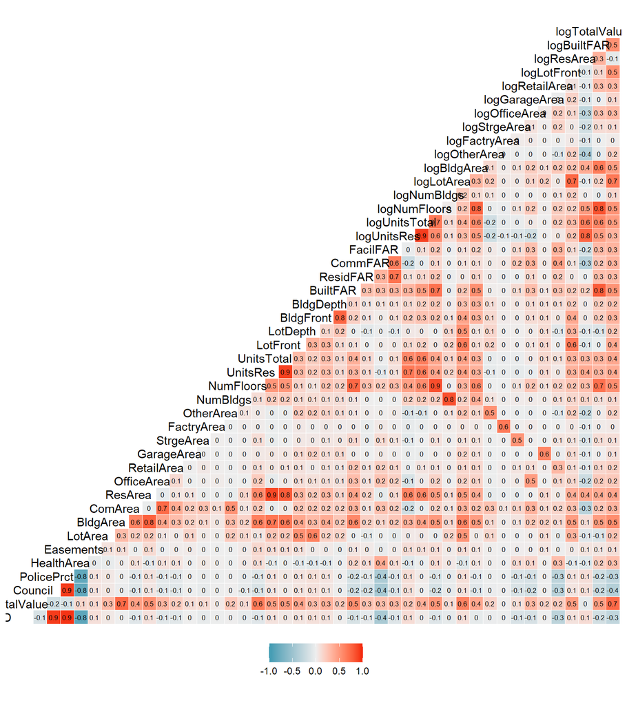

# Acknowledgments

Some of the code was borrowed from the Data Science 1: Machine Learning Concepts labs. I would like to extend my gratitude to Zoltan Papp, Jano Pal, and Divenyi Janos for allowing us to use the code.